# What does your Prosper Rating say about you?

## by Atonye Eben-Foby

## Investigation Overview:

The goal of this presentation is to provide insights into the following:

- The distribution or borrower APR in the data set.
- The percentage of loans in each prosper rating category.
- The relationship between income range and prosper rating.
- The relationship between the loan status and the prosper rating.
- The relationship between loan original amount, monthly loan payment and stated monthly income.
- Home Ownership status VS Borrower APR.
- The relationship between prosper rating, borrower APR and estimated return

## Dataset Overview

This data set from Prosper MarketPlace contains 113,937 loans with 81 variables on each loan, including loan amount, borrower rate (or interest rate), current loan status, borrower income, and many others.

## What is the distribution Borrower APR in the dataset?

The histogram of BorrowerAPR'S in the dataset is a mesokurtic multimodal distribution with a mean of about 0.2 and the APR with the highest count in the dataset falls with 0.15 and 0.18

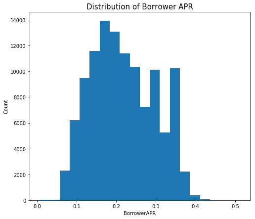

## What Percentage of Loans fall into each Rating Category?

From the barchart, We can see the percentage of loans in each prosper rating category. The highest proportion (21%) of the data are C rated. Only 9.3% of borrowers are classified as high risk and 7.8% of borrowers belong to the highest rated category, AA.

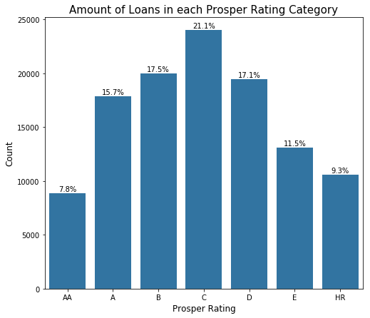

## The relationship between the Income Range and Prosper Rating.

Income Range is one of the factors that affects a borrowers Prosper rating. From this clustered bar chart we can see that smallest proportion of borrowers in the highest prosper rating category AA belong to the income range category \$1 - 24,999. If we also look at the high risk category HR, the smallest proportion of borrowers in this category have an income range of \\$100,000+

While income range isn't the only factor that determines a borrowers prosper rating, it is obviously an important one.

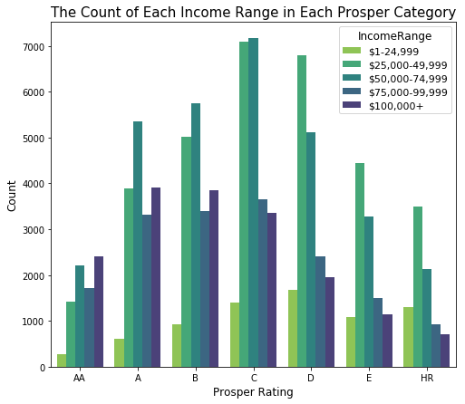

## The relationship between the loan status and the prosper rating.

For this illustration I will be focusing on loan status categories Current, Completed and Defaulted. The bar chart shows that the largest proportion of defaulted loans were given the HR prosper rating at the time the listing was created. This proves that the model used to place borrowers into prosper ratings is an accurated prediction of borrower behavior.

We can also see that the largest count of current loans belongs to the C rating category and the largest count of completed loans fall into the D category.

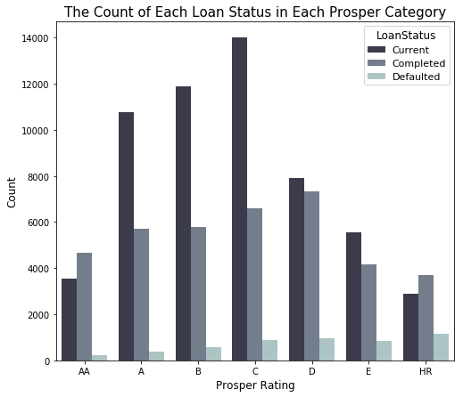

## The relationship between loan original amount, monthly loan payment and stated monthly income.

The scatter plot shows a positive correlation betweeen the loan original amount and the monthly loan payment. This means that borrowers that take out higher loans typically pay back higher amounts monthly.

There is also no correlation between the borrowers stated monthly income and the amount they take out in loans. Therefore monthly income alone can not be used to predict borrower behavior.

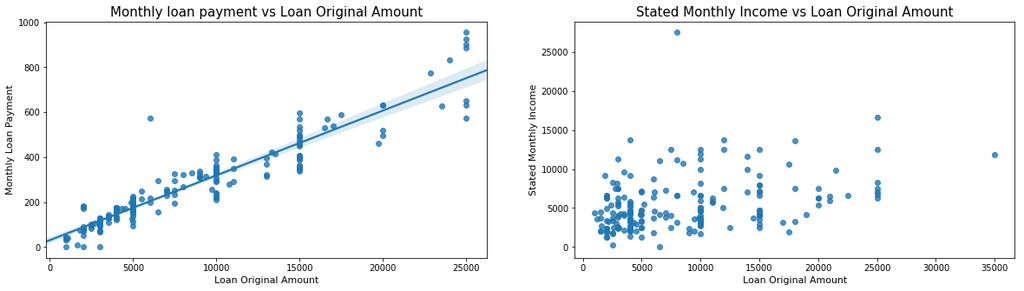

## Home ownership status vs Borrower APR

Investigation into the relationship between home ownership status and Borrower APR revealed that home owners have lower APR values than non home owners. This is probably due to the fact that homeowners are usually classified as lower risk since the house can be used as collateral if there is a default in payment.

A further look into the descriptive statistics proves that it's not only the mean that is higher for non home owners. The first quartile, median, third quartile all share this relationship.

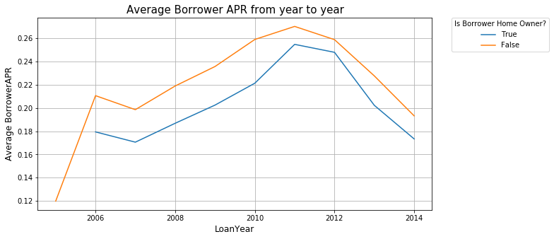

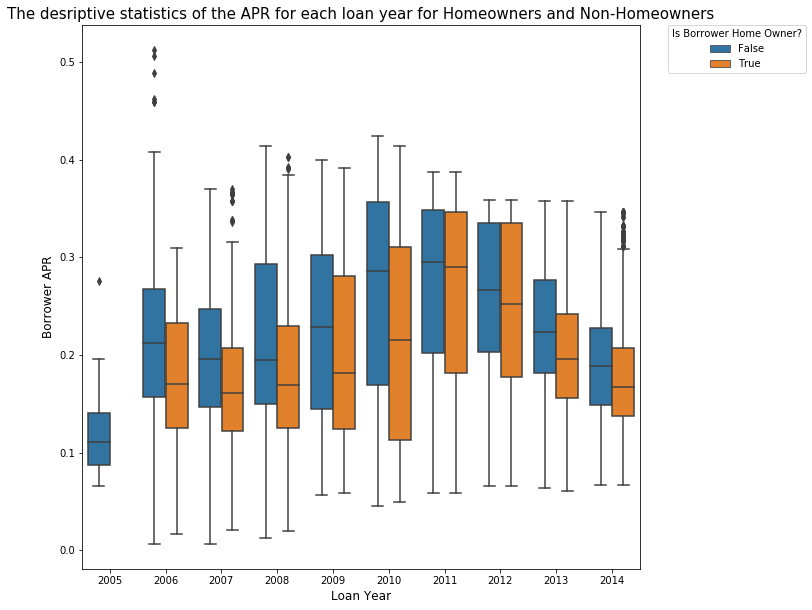

## The relationship between Prosper Rating, Borrower APR and Estimated Return

The average borrower APR and Estimated Return were at their maximum in 2011. The comparison of these two variables revealed a positive correlation. This means that as the APR value increases so does the Estimated return and vice versa.A further look into how the prosper rating affects the estimated return reveals that estimated return is highest at low prosper rating categories D,E and HR. An analysis into the count of loans in each rating category in 2011 compared to other years shows that a higher percentage of loans in 2011 were taken by borrowers with low prosper ratings than the other years.

**So what happened in 2011?**

In 2011 Prosper Marketplace gave out more loans to borrowers in categories D,E and HR than any other year in the dataset. As a result of this the average estimated return and the average APR value were at their maximum.

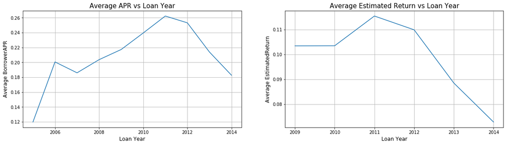

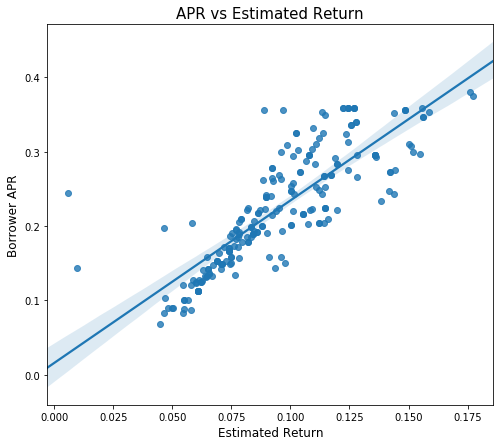

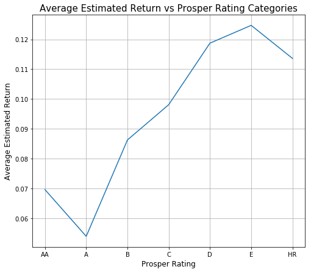

```
array(['C', 'A', 'HR', 'D', 'B', 'E', 'AA'], dtype=object)
```

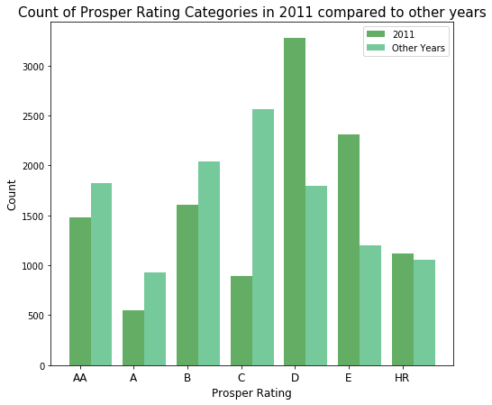